# Double Q Agent with Prioritized Experience Replay

*Version:* `1.0` *(Jupytext, time measurements, logger)*

# Table of Content

- Notebook Description
- General Settings
  - Paths
  - Notebook Functionality and Appearance
  - External Libraries
  - Internal Code
  - Constants
- Analysis
  - Functions
  - Creating Environment
  - Training Agent
  - Plotting Results
- Final Timestamp

# Notebook Description

ToC

# GENERAL SETTINGS

ToC  
General settings for the notebook (paths, python libraries, own code, notebook constants).

> *NOTE: All imports and constants for the notebook settings shoud be here. Nothing should be imported in the analysis section.*

### Paths

ToC

Adding paths that are necessary to import code from within the repository.

```python
import sys
import os
sys.path+=[os.path.join(os.getcwd(), ".."), os.path.join(os.getcwd(), "../..")] # one and two up
```

### Notebook Functionality and Appearance

ToC  
Necessary libraries for notebook functionality:

- A button for hiding/showing the code. By default it is deactivated and can be activated by setting CREATE_BUTTON constant to True.

  > **NOTE: This way, using the function, the button works only in active notebook. If the functionality needs to be preserved in html export, then the code has to be incluced directly into notebook.**
- Set notebook width to 100%.
- Notebook data frame setting for better visibility.
- Initial timestamp setting and logging the start of the execution.

```python
# from src.utils.notebook_support_functions import create_button, get_notebook_name
from src.utils.logger import Logger
from src.utils.envs import Envs
from src.utils.config import Config
from pandas import options
from IPython.display import display, HTML
```

> Constants for overall behaviour.

```python
LOGGER_CONFIG_NAME = "logger_file" # default
PYTHON_CONFIG_NAME = "python_repo" # default
CREATE_BUTTON = False
ADDAPT_WIDTH = False
NOTEBOOK_NAME = "02_double_q_agent_with_PER_training" # get_notebook_name()
```

```python
options.display.max_rows = 500
options.display.max_columns = 500
envs = Envs()
envs.set_logger(LOGGER_CONFIG_NAME)
envs.set_config(PYTHON_CONFIG_NAME)
Logger().start_timer(f"NOTEBOOK; Notebook name: {NOTEBOOK_NAME}")
if CREATE_BUTTON:
    create_button()
if ADDAPT_WIDTH:
    display(HTML("<style>.container { width:100% !important; }</style>")) # notebook width
```

```
A: ../../configurations\logger_file.conf
```

### External Libraries

ToC

```python
import gym
from collections import deque
from numpy import mean
from typing import List

from importlib import reload

import matplotlib.pyplot as plt
from IPython.display import clear_output
```

### Internal Code

ToC  
Code, libraries, classes, functions from within the repository.

```python
from src.data.replay_buffer import ReplayBuffer
from src.models.torch_networks import QNetwork, QNetworkDropout, DuelingQNetwork, DuelingQNetworkDropout
from src.models.agents import DQNAgent, DQNAgentPER

from src.utils.timer import Timer
```

### Constants

ToC  
Constants for the notebook.

> *NOTE: Please use all letters upper.*

#### General Constants

ToC

```python
# from src.constants.global_constants import *  # Remember to import only the constants in use
N_ROWS_TO_DISPLAY = 2
FIGURE_SIZE_SETTING = {"autosize": False, "width": 2200, "height": 750}
```

#### Constants for Setting Automatic Run

ToC

```python
NETWORK = "DUEL-Q" # "Q", "DUEL-Q"
DROPOUT = False

EPS_DECAY = 0.995
GAMMA = 0.99

UPDATE_EVERY_STEP = 4
HARD_UPDATE_EVERY_STEPS = 4
# STEPS_UPDATE = (2, 8) # UPDATE_EVERY_STEP, HARD_UPDATE_EVERY_STEPS

ALPHA = 0.2
BETA_START = 0.6
```

#### Notebook Specific Constants

ToC

```python
ENV_ID = "LunarLander-v2" # "LunarLander-v2" "CartPole-v1"

ACTIONS_DIM = 1
MEMORY_SIZE = 2**14 # 2**14 = 16384
BATCH_SIZE = 64

EPS_START = 1.0
EPS_END = 0.01
```

```python
2**14
```

```
16384
```

# ANALYSIS

ToC

```python
timer = Timer()
```

## Functions

ToC

```python
def plot(x_data: List[int], y_data: List[float], plot_title: str, y_label: str) -> None:
    """
    Creats simple plot.
    """
    plt.figure(figsize=(15, 6), dpi=80)
    plt.title(plot_title)
    plt.xlabel("Episode Number")
    plt.ylabel(y_label)
    plt.plot(x_data, y_data, "g", linewidth=2)
    plt.show()
```

## Creating Environment

ToC

```python
env = gym.make(ENV_ID)
```

## Training Agent

ToC

```python
net = None
if NETWORK == "Q":
    if DROPOUT:
        net = QNetworkDropout
    else:
        net = QNetwork
if NETWORK == "DUEL-Q":
    if DROPOUT:
        net = DuelingQNetworkDropout
    else:
        net = DuelingQNetwork
```

```python
agent = DQNAgentPER(env, ACTIONS_DIM, MEMORY_SIZE, BATCH_SIZE, net, GAMMA, ALPHA)

agent.set_optimizing_parameters(update_every_steps=UPDATE_EVERY_STEP, hard_update_every_steps=HARD_UPDATE_EVERY_STEPS, tau=0.001)
```

```python
n_episodes = 4000
max_steps_in_episode = 1000
eps_start = EPS_START
eps_end = EPS_END
eps_decay = EPS_DECAY
beta_start = BETA_START

# storing data for plotting
episodes_indices = []
epss = []
avg_scores = []
betas = []
# (end) storing data for plotting

scores = []
scores_window = deque(maxlen=100)
eps = eps_start
beta = beta_start
timer.start()
for episode in range(1, n_episodes+1):
    state, _ = env.reset()
    score = 0

    for step in range(max_steps_in_episode):
        action = agent.act(state, eps)
        next_state, reward, done = agent.step(action)
        agent.learn(beta)

        state = next_state
        score = score + reward
        if done:
            break
    scores.append(score)
    scores_window.append(score)
    eps = max(eps_end, eps_decay * eps)
    fraction = min(episode / n_episodes, 1.0)
    beta = beta_start + fraction * (1.0 - beta_start)

    if episode % (n_episodes / 100) == 0:
        episodes_indices.append(episode)
        epss.append(eps)
        avg_scores.append(mean(scores_window))
        betas.append(beta)
    print(f"## Episode Number: {episode}, Average Score: {mean(scores_window)}", end="\r")
    if episode % (n_episodes / 50) == 0:
        secs, mins = timer.get_meantime()
        print(f"## Episode Number: {episode}, Average Score: {mean(scores_window)}, Duration[s], [mins]: "
              f"{secs}, {mins}{' '*20}")
    if mean(scores_window)>=210.0:
        print("\n")
        print(f"## ENVIRONMENT SOLVED ##")
        print(f"  - Number of Episodes: {episode - 100}")
        print(f"  - Average Score: {mean(scores_window)}")
        model_file_name = agent.save_model()
        print(f"  - Model Was Saved Into File: {model_file_name}")
        break
```

```
Date and Time of Starting Execution: 07/02/2023 09:51:21
## Episode Number: 80, Average Score: -132.8984727488102, Duration[s], [mins]: 17.36, 0.29
## Episode Number: 160, Average Score: -88.50952304313776, Duration[s], [mins]: 37.17, 0.62
## Episode Number: 240, Average Score: -0.9083302984358518, Duration[s], [mins]: 122.46, 2.04
## Episode Number: 320, Average Score: 54.83544903526857, Duration[s], [mins]: 139.01, 2.32
## Episode Number: 400, Average Score: 131.7749347424175, Duration[s], [mins]: 119.29, 1.99
## Episode Number: 480, Average Score: 172.7784676392335, Duration[s], [mins]: 85.67, 1.43
## Episode Number: 560, Average Score: 186.94076182151576, Duration[s], [mins]: 99.92, 1.67
## Episode Number: 609, Average Score: 210.30060688249526

## ENVIRONMENT SOLVED ##
  - Number of Episodes: 509
  - Average Score: 210.3006068824952
  - Model Was Saved Into File: 2023-02-07-11-02-39_model_checkpoint.pth
```

```python
timer.end()
```

```
Duration of: None is 57.66 s, 0.96 mins.
Date and Time of Ending Execution: 07/02/2023 10:02:39
Overall Duration is: 678.53 s, 11.31 mins.
```

## Plotting the Results

ToC

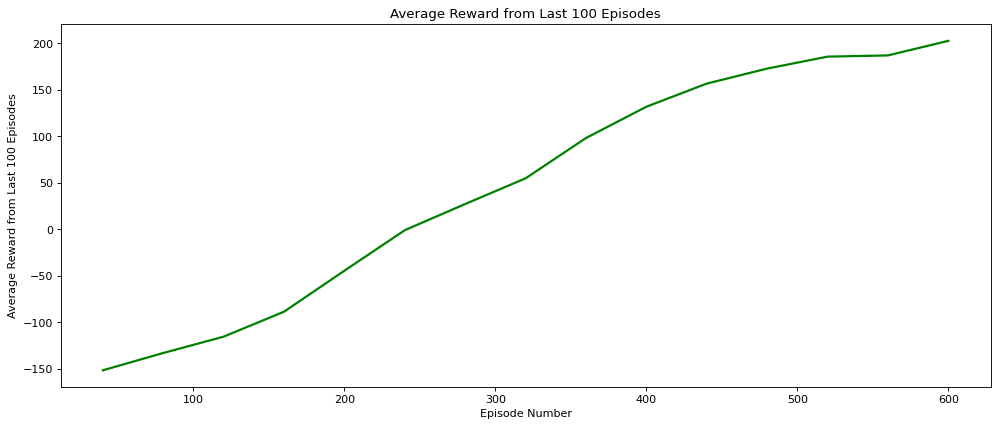

```python
plot_title = "Average Reward from Last 100 Episodes"
y_label = "Average Reward from Last 100 Episodes"
plot(episodes_indices, avg_scores, plot_title, y_label)
```

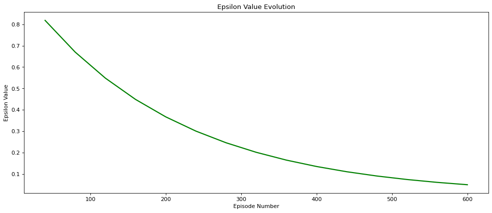

```python
plot_title = "Epsilon Value Evolution"
y_label = "Epsilon Value"
plot(episodes_indices, epss, plot_title, y_label)
```

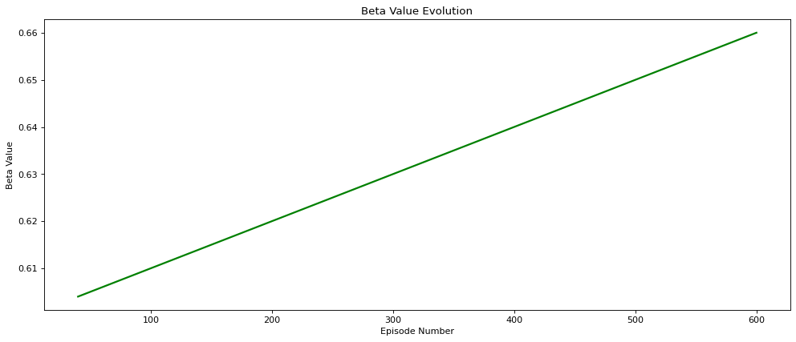

```python
plot_title = "Beta Value Evolution"
y_label = "Beta Value"
plot(episodes_indices, betas, plot_title, y_label)
```

# Final Timestamp

ToC

```python
Logger().end_timer()
```